# main

## **Credit Card Default Classification**

Name: Ryan Yeo

Admin Number: P2214452

Class: DAAA/FT/2A/01

## **Background Research**

#### **Objective**

Use a supervised classification machine learning model to predict the likelihood of credit card default for customers of the Bank

#### **Credit Card Default Explanation**

The dataset was collected from a credit card provider.

*Credit* is the ability of the consumer to purchase goods and services prior to payment with the faith that payment will be made in the future.

Each consumer has their own *Creditworthiness*, which is usually measured by *Credit Score*, is a measure of the consumer's ability to pay back the credit they have borrowed. Consumer's with a higher Credit Score are less likely to default and will usually be given a higher credit limit.

#### **Factors used in predicting default**

[figure not shown]

Some factors that affect a consumer's Credit Score include:

- Payment History => Lenders usually base the amount of risk on whether consumers have past credit accounts on time
- Amounts Owed => Outstanding Balance
- New Credit => Lenders dislike consumers that open new credit accounts in a short perio of time
- Length of Credit History => Lenders prefer Credit Accounts that are established for a longer time
- Credit Mix => Lenders like to see a healthy mix of credit such as Mortgages, Installment Loans and Retail Accounts etc.

```python
# Basic libraries
import numpy as np
import pandas as pd
import matplotlib.pyplot as plt
import seaborn as sns

# SKLEARN Libraries

# Model Selection
from sklearn.model_selection import (
    train_test_split,
    cross_validate,
    cross_val_score,
    GridSearchCV,
    cross_val_predict,
    learning_curve,
    StratifiedKFold,
)

from sklearn.metrics import classification_report, confusion_matrix, RocCurveDisplay, make_scorer, fbeta_score, roc_auc_score, balanced_accuracy_score
# Pipeline
from imblearn.pipeline import Pipeline

# Models
from sklearn.dummy import DummyClassifier
from sklearn.tree import DecisionTreeClassifier
from sklearn.ensemble import RandomForestClassifier
from sklearn.ensemble import AdaBoostClassifier
from sklearn.linear_model import LogisticRegression
from sklearn.neighbors import KNeighborsClassifier
from sklearn.ensemble import GradientBoostingClassifier
from sklearn.linear_model import Perceptron
from sklearn.naive_bayes import GaussianNB

# Preprocessing
from sklearn.compose import ColumnTransformer
from sklearn.preprocessing import FunctionTransformer, StandardScaler, OrdinalEncoder, OneHotEncoder

# Oversampling
from imblearn.over_sampling import SMOTENC

# Saving models
import pickle
```

```python
# Set random state
random_state = 42
```

```python
df = pd.read_csv('credit_dataset.csv')
display(df.head())
```

|  | Customer ID | Credit Limit | Gender | Education | Marriage Status | Age | Bill_Amount1 | Bill_Amount2 | Bill_Amount3 | Pay_Amount1 | Pay_Amount2 | Pay_Amount3 | Default payment next month |
| --- | --- | --- | --- | --- | --- | --- | --- | --- | --- | --- | --- | --- | --- |
| 0 | 1 | 20000 | female | univeresity | married | 24 | 3913 | 3102 | 689 | 0 | 689 | 0 | 1 |
| 1 | 2 | 120000 | female | univeresity | single | 26 | 2682 | 1725 | 2682 | 0 | 1000 | 1000 | 1 |
| 2 | 3 | 90000 | female | univeresity | single | 34 | 29239 | 14027 | 13559 | 1518 | 1500 | 1000 | 0 |
| 3 | 4 | 50000 | female | univeresity | married | 37 | 46990 | 48233 | 49291 | 2000 | 2019 | 1200 | 0 |
| 4 | 5 | 50000 | male | univeresity | married | 57 | 8617 | 5670 | 35835 | 2000 | 36681 | 10000 | 0 |

## 1. EDA

```python
print(list(df.columns))
```

```
['Customer ID', 'Credit Limit', 'Gender', 'Education', 'Marriage Status', 'Age', 'Bill_Amount1', 'Bill_Amount2', 'Bill_Amount3', 'Pay_Amount1', 'Pay_Amount2', 'Pay_Amount3', 'Default payment next month']
```

Rename some of the columns

```python
# Rename columns
df = df.rename(
    columns={
        "Credit Limit": "Credit_Limit",
        "Marriage Status": "Marriage_Status",
        "Bill_Amount1": "Bill1",
        "Bill_Amount2": "Bill2",
        "Bill_Amount3": "Bill3",
        "Pay_Amount1": "Pay1",
        "Pay_Amount2": "Pay2",
        "Pay_Amount3": "Pay3",
        "Default payment next month": "Will_Default"
    }
)
```

```python
print(f"Shape: {df.shape}")
print(df.info())
```

```
Shape: (1600, 13)
<class 'pandas.core.frame.DataFrame'>
RangeIndex: 1600 entries, 0 to 1599
Data columns (total 13 columns):
 #   Column           Non-Null Count  Dtype
---  ------           --------------  -----
 0   Customer ID      1600 non-null   int64
 1   Credit_Limit     1600 non-null   int64
 2   Gender           1600 non-null   object
 3   Education        1600 non-null   object
 4   Marriage_Status  1600 non-null   object
 5   Age              1600 non-null   int64
 6   Bill1            1600 non-null   int64
 7   Bill2            1600 non-null   int64
 8   Bill3            1600 non-null   int64
 9   Pay1             1600 non-null   int64
 10  Pay2             1600 non-null   int64
 11  Pay3             1600 non-null   int64
 12  Will_Default     1600 non-null   int64
dtypes: int64(10), object(3)
memory usage: 162.6+ KB
None
```

**Data Dictionary**

| Column Name | Data Type | Definition |
| --- | --- | --- |
| Customer ID | Primary Key | Unique Customer identifier ranging from 1 to 1600 |
| Credit_Limtit | Numeric | Credit limit for the customer |
| Gender | Nominal Category | Customer's gender |
| Education | Ordinal Category | Customer's education level |
| Marriage_Status | Nominal Category | Customer's Marital Status |
| Age | Numeric | Customer's Age |
| Bill1 | Numeric | Credit card bill amount 1 month ago |
| Bill2 | Numeric | Credit card bill amount 2 month ago |
| Bill3 | Numeric | Credit card bill amount 3 month ago |
| Pay1 | Numeric | Amount customer paid 1 month ago |
| Pay2 | Numeric | Amount customer paid 2 month ago |
| Pay3 | Numeric | Amount customer paid 3 month ago |
| Will_Default | Target Variable | Whether customer will default next month |

The target variable of the dataset is *Will_Default* which means that the goal is to try and predict whether the customers will default the payment for their credit card the next month. *Will_Default* has two values, 0 and 1.

0 stands for 'non default' which means that the customer will pay their bill while 1 stands for 'default' which means that the customer will not pay their bill

```python
# Convert columns to category
df[['Gender', 'Education', 'Marriage_Status', 'Will_Default']] = df[['Gender', 'Education', 'Marriage_Status', 'Will_Default']].apply(lambda x: x.astype('category'))
```

Check all unique values in the categorical features

```python
print(f"Gender: {list(df['Gender'].unique())}")
print(f"Education: {list(df['Education'].unique())}")
print(f"Marriage_Status: {list(df['Marriage_Status'].unique())}")
```

```
Gender: ['female', 'male']
Education: ['univeresity', 'post-graduate', 'high school']
Marriage_Status: ['married', 'single']
```

Rename "univeresity" to "university"

```python
df['Education'] = df['Education'].apply(lambda x: 'university' if x == 'univeresity' else x)
print(df['Education'].unique())
```

```
['university', 'post-graduate', 'high school']
Categories (3, object): ['high school', 'post-graduate', 'university']
```

Notice that the order inside education is 'high school' -> 'post-graduate' -> 'university'. Since 'post-graduate' is higher than 'university' (assuming university means undergraduate) we would have to adjust the order of the categories

```python
# Adjust order of categories within Education
df['Education'] = df['Education'].cat.reorder_categories(['high school', 'university', 'post-graduate'])
print(df['Education'].unique())
```

```
['university', 'post-graduate', 'high school']
Categories (3, object): ['high school', 'university', 'post-graduate']
```

```python
print("SUMMARY STATISTICS OF NUMERIC COLUMNS")
display(df.describe().T)
```

```
SUMMARY STATISTICS OF NUMERIC COLUMNS
```

|  | count | mean | std | min | 25% | 50% | 75% | max |
| --- | --- | --- | --- | --- | --- | --- | --- | --- |
| Customer ID | 1600.0 | 800.500000 | 462.024530 | 1.0 | 400.75 | 800.5 | 1200.25 | 1600.0 |
| Credit_Limit | 1600.0 | 166787.500000 | 129944.635707 | 10000.0 | 50000.00 | 140000.0 | 230000.00 | 700000.0 |
| Age | 1600.0 | 35.224375 | 9.404550 | 21.0 | 28.00 | 34.0 | 41.00 | 75.0 |
| Bill1 | 1600.0 | 49263.408125 | 72687.106917 | -14386.0 | 3138.00 | 20320.5 | 61602.75 | 507726.0 |
| Bill2 | 1600.0 | 47726.644375 | 71476.217397 | -13543.0 | 3288.25 | 19769.5 | 59891.75 | 509229.0 |
| Bill3 | 1600.0 | 44531.051875 | 67164.064239 | -9850.0 | 2321.50 | 19332.5 | 53857.25 | 499936.0 |
| Pay1 | 1600.0 | 5547.646250 | 14085.471957 | 0.0 | 1000.00 | 2176.5 | 5021.00 | 239104.0 |
| Pay2 | 1600.0 | 5230.494375 | 15569.605419 | 0.0 | 468.50 | 1904.0 | 4592.50 | 285138.0 |
| Pay3 | 1600.0 | 4451.610625 | 12491.715387 | 0.0 | 226.50 | 1313.5 | 4000.00 | 222750.0 |

```python
# Display negative bills and will default
print("NEGATIVE BILLS AND WILL DEFAULT")
print(df['Will_Default'][(df.Bill1 < 0) | (df.Bill2 < 0) | (df.Bill3 < 0)].value_counts())
```

```
NEGATIVE BILLS AND WILL DEFAULT
0    47
1    16
Name: Will_Default, dtype: int64
```

Check for missing values

```python
print(df.isnull().sum())
```

```
Customer ID        0
Credit_Limit       0
Gender             0
Education          0
Marriage_Status    0
Age                0
Bill1              0
Bill2              0
Bill3              0
Pay1               0
Pay2               0
Pay3               0
Will_Default       0
dtype: int64
```

To prevent the mutation of our original dataset, we will make a copy of it for our EDA

```python
df_eda = df.copy()
```

```python
df_eda['Will_Default'].unique()
```

```
[1, 0]
Categories (2, int64): [0, 1]
```

```python
df_eda['Will_Default'] = df_eda['Will_Default'].map({0: 'Non Default', 1: 'Default'})
```

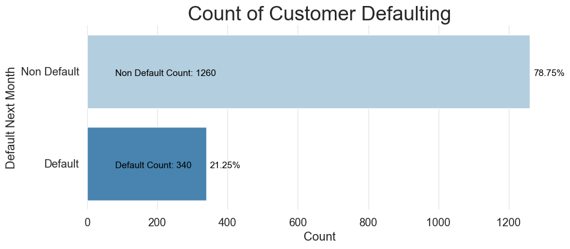

```python
# Edit seaborn style
plt.figure(figsize=(10, 4))
sns.set_context('notebook', font_scale=1.2)
# Set grid color
sns.set_style('whitegrid', {'grid.color': '0.9'})
# Remove the frame
plt.box(False)

# Plot bar plot
sns.countplot(y=df_eda['Will_Default'], palette="Blues")

# Get actual numbers to annotate the plot
default = df_eda['Will_Default'].value_counts()['Default']
non_default = df_eda['Will_Default'].value_counts()['Non Default']

# Annotations
plt.annotate(f"{(non_default/(default+non_default))*100:.2f}%", xy = (1270, 0.05), fontsize=11, color='black')
plt.annotate(f"Non Default Count: {non_default}", xy = (80, 0.05), fontsize=11, color='black')
plt.annotate(f"Default Count: {default}", xy = (80, 1.05), fontsize=11, color='black')
plt.annotate(f"{(default/(default+non_default))*100:.2f}%", xy = (350, 1.05), fontsize=11, color='black')

# Set labels
plt.xlabel('Count')
plt.ylabel('Default Next Month')

# Set title
plt.title('Count of Customer Defaulting', fontsize=24)

plt.show()
```

**Observations**

As seen in this graph, the dataset is imbalanced with only 21.25% of the customers defaulting their payment.

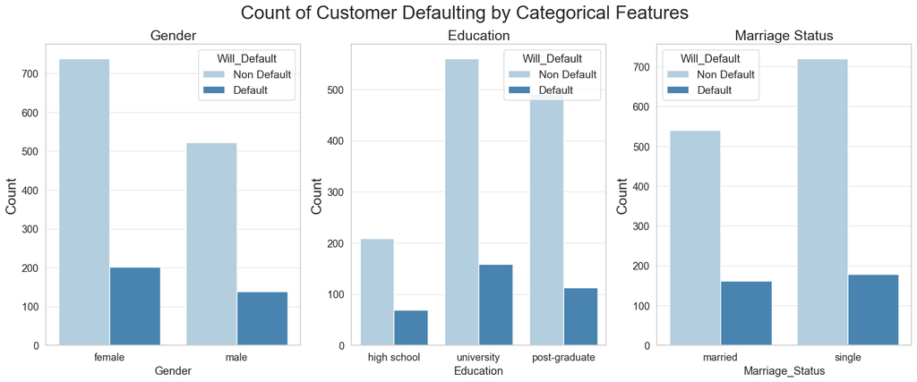

```python
# Plot bar plot of each categorical feature against the target variable
categorical = df_eda[df_eda.select_dtypes(include=['category']).columns.tolist()]
sns.set_context('notebook', font_scale=1.2)
# Set grid color
sns.set_style('whitegrid', {'grid.color': '0.9'})

fig, axes = plt.subplots(1, 3, figsize=(20,7))
# Set title
fig.suptitle('Count of Customer Defaulting by Categorical Features', fontsize=24)

for ax, catplot in zip(axes, categorical):
    sns.countplot(x=catplot, hue='Will_Default', data=categorical, palette='Blues', ax=ax)
    ax.set_ylabel('Count', fontsize=18)
    ax.legend(title='Will_Default', fontsize=14)
    ax.set_title(catplot.replace('_', ' '), fontsize=18)
```

**Observations**:

- Females seem to default more than males but this may also be because there are more females in the dataset than males
- The number of single and married people who default are around the same and since there are a lot more single people than married people in the dataset, it means that on average, someone who is single is less likely to default compared to someone who is married
- University graduates seem to default more than post-graduate and high school graduates but it may also be because there are more university graduates

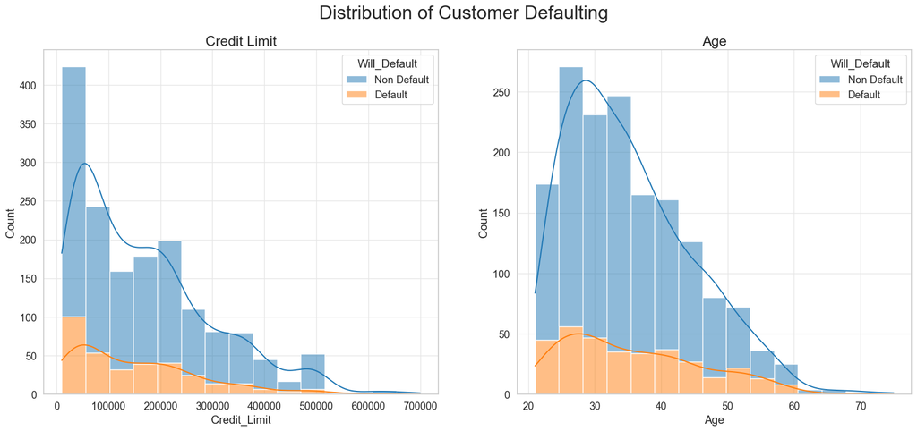

```python
# Plot distribution of each numeric feature against the target variable
numeric = df_eda[['Credit_Limit', 'Age', 'Bill1', 'Bill2', 'Bill3', 'Pay1', 'Pay2', 'Pay3', 'Will_Default']]
sns.set_context('notebook', font_scale=1.2)
# Set grid color
sns.set_style('whitegrid', {'grid.color': '0.9'})

fig, axes = plt.subplots(1, 2, figsize=(20,8))

# Set title
fig.suptitle('Distribution of Customer Defaulting', fontsize=24)

# Plot distribution of Credit_Limit
sns.histplot(ax=axes[0], data=numeric, x='Credit_Limit',hue='Will_Default', multiple='stack', bins=15, kde=True)
# Set subtitle
axes[0].set_title('Credit Limit', fontsize=18)

# Plot distribution of Age
sns.histplot(ax=axes[1], data=numeric, x='Age',hue='Will_Default', multiple='stack', bins=15, kde=True)
# Set subtitle
axes[1].set_title('Age', fontsize=18)

plt.show()
```

**Observations**:

- The distribution of credit limit is positively skewed with a mode at around 50000 for both defaulters and non defaulters
- The distribution of age is also positively skewed with a mode at around 30 years old for both defaulters and non defaulters

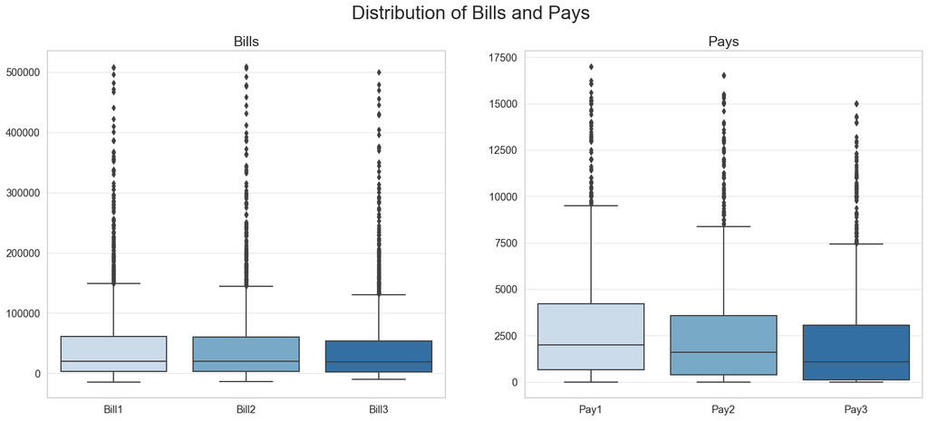

```python
# Plot distribution of bills and pays
bills = df_eda[['Bill1', 'Bill2', 'Bill3']]
pays = df_eda[['Pay1', 'Pay2', 'Pay3']]

# Remove extreme outliers from pays using IQR
Q1 = pays.quantile(0.25)
Q3 = pays.quantile(0.75)
IQR = Q3 - Q1
pays = pays[~((pays < (Q1 - 3 * IQR)) |(pays > (Q3 + 3 * IQR))).any(axis=1)]

sns.set_context('notebook', font_scale=1.2)
sns.set_style('whitegrid', {'grid.color': '0.9'})

fig, axes = plt.subplots(1, 2, figsize=(20,8))

# Set title
fig.suptitle('Distribution of Bills and Pays', fontsize=24)

# Plot distribution of bills
sns.boxplot(ax=axes[0], data=bills, palette='Blues')
# Set subtitle
axes[0].set_title('Bills', fontsize=18)

# Plot distribution of pays
sns.boxplot(ax=axes[1], data=pays, palette='Blues')
# Set subtitle
axes[1].set_title('Pays', fontsize=18)

plt.show()
```

**Observations**:

- The distribution of Bill1, Bill2 and Bill3 seem extremely similar so those three features might actually be collinear
- The distribution of Pay1, Pay2 and Pay3 are not as similar with Pay1 having the highest median followed by Pay2 then Pay3
- There seems to be a lot of outliers within the dataset for the Bill and Pay features

#### **Pearon's r Correlation**

To check the correlation between the different numerical features, we will use Pearson's r correlation. The Pearson's r correlation is able to measure linear correlation between two variables.

**Formula**: $\begin{equation} \rho = \frac{COV(X,Y)}{\sigma_X\sigma_Y} \end{equation}$

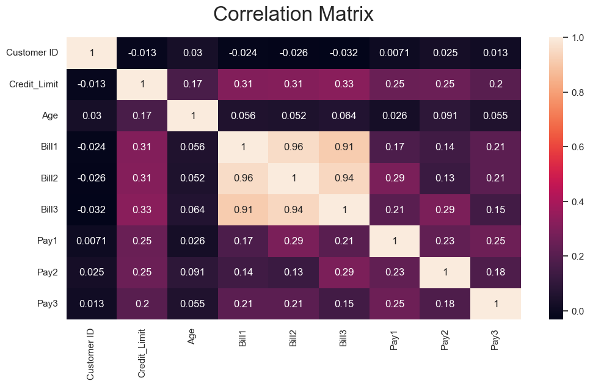

```python
# Plot correlation matrix
plt.figure(figsize=(12, 6))

# Set font scale
sns.set_context('notebook', font_scale=1)

# Set grid color
sns.set_style('whitegrid', {'grid.color': '0.9'})

# Remove the frame
plt.box(False)

# Plot heatmap
sns.heatmap(df_eda.corr(), annot=True)

# Set title
plt.title('Correlation Matrix', fontsize=24, pad=20)

plt.show()
```

**Observations**

- We can see that Bill1, Bill2 and Bill 3 have a very high positive correlation value at >0.9 confirming the fact that they are likely collinear
- However, for the other variables, there is no clear correlations between them

```python
print(df_eda['Will_Default'].value_counts())
```

```
Non Default    1260
Default         340
Name: Will_Default, dtype: int64
```

## 2. Data Preparation

Drop Customer ID since it is a redundant column

```python
df.drop('Customer ID', axis=1, inplace=True)
print(df.info())
```

```
<class 'pandas.core.frame.DataFrame'>
RangeIndex: 1600 entries, 0 to 1599
Data columns (total 12 columns):
 #   Column           Non-Null Count  Dtype
---  ------           --------------  -----
 0   Credit_Limit     1600 non-null   int64
 1   Gender           1600 non-null   category
 2   Education        1600 non-null   category
 3   Marriage_Status  1600 non-null   category
 4   Age              1600 non-null   int64
 5   Bill1            1600 non-null   int64
 6   Bill2            1600 non-null   int64
 7   Bill3            1600 non-null   int64
 8   Pay1             1600 non-null   int64
 9   Pay2             1600 non-null   int64
 10  Pay3             1600 non-null   int64
 11  Will_Default     1600 non-null   category
dtypes: category(4), int64(8)
memory usage: 106.9 KB
None
```

```python
X, y = df.drop('Will_Default', axis=1), df['Will_Default']
```

```python
# Split data into train and test set
X_train, X_test, y_train, y_test = train_test_split(X, y, test_size=0.2, stratify=y, shuffle=True, random_state=random_state)
```

```python
print(f"X_train shape: {X_train.shape}")
print(f"X_test shape: {X_test.shape}")
```

```
X_train shape: (1280, 11)
X_test shape: (320, 11)
```

#### **Dealing with imbalanced datasets**

As seen previously, our dataset is imblanaced with 1260 records of customers not defaulting and only 340 records of customers defaulting.

We can deal with our imbalanced dataset during different steps of the ML Workflow:

- During Data Preprocessing
  1. Oversampling
  2. Undersampling
- Using Evaluation Metrics
  - Using Balanced Accuracy inplace of Accuracy
- Using a different Model
  - Try using a different perspective like using Anomaly Detection algorithms instead of a supervised learning approach
  - Using Penalized classification to impose an additional cost on the model for making mistakes on the minority class during training

*Note the list only includes methods that are more common. There exist a lot of other techniques to deal with imbalanced dataset*

References:

- https://stats.stackexchange.com/questions/463224/which-performance-metrics-for-highly-imbalanced-multiclass-dataset

Oversampling vs Undersampling:

[figure not shown]

*Fig 1: Undersampling vs Oversampling*

Despite the advantage of balancing classes through resampling, these techniques also have their weaknesses.

One of the basic ways to perform **oversampling** is to duplicate random records from the minority class but this approach may lead to overfitting issues by creating redundant samples.

In **undersampling**, the simplest technique involves randomly discarding records from the majority class but this can result in a loss of information that may be necessary to train the model accurately

In this case, we will be using SMOTE (or more specifically SMOTE-NC which is a variant of SMOTE designed specifically for datasets with nominal and continuous features). SMOTE is a more sophisticated resampling technique whereby instead of just randomly duplicating existing records from the minority class, it would:

1. Randomly pick a record from the minority class
2. Compute the k-nearest neighbours for this point
3. Choose one of the neighbours and place a synthetic point anywhere on the line joining the point and its chosen neighbour

```python
# https://imbalanced-learn.org/dev/references/generated/imblearn.over_sampling.SMOTENC.html
# Obtain a list of categorical columns
categorical_features = X_train.select_dtypes(include=['category']).columns
# Obtain column index for categorical columns
categorical_features_idx = [X_train.columns.get_loc(col) for col in categorical_features]
# Instantiate SMOTENC
sm = SMOTENC(random_state=random_state, categorical_features=categorical_features_idx)
X_res, y_res = sm.fit_resample(X_train, y_train)
```

```python
print(f"X resampled shape: {X_res.shape}")
```

```
X resampled shape: (2016, 11)
```

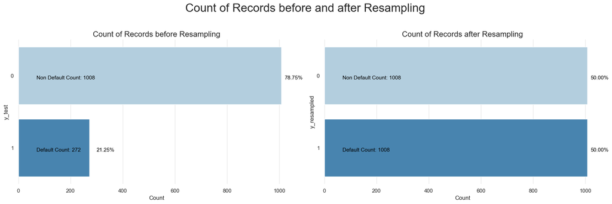

```python
fig, ax = plt.subplots(1, 2, figsize=(18, 6))

# Edit seaborn style
sns.set_context('notebook', font_scale=1.2)
# Set grid color
sns.set_style('whitegrid', {'grid.color': '0.9'})
# Set title
plt.suptitle('Count of Records before and after Resampling', fontsize=24)

# Set padding between title and plots
plt.tight_layout(pad=2.0)

# Before Resampling
sns.countplot(y=y_train, palette="Blues", ax=ax[0])
# Remove the frame
ax[0].spines['top'].set_visible(False)
ax[0].spines['right'].set_visible(False)
ax[0].spines['left'].set_visible(False)
ax[0].spines['bottom'].set_visible(False)

# Get actual numbers to annotate the plot
default = y_train.value_counts()[1]
non_default = y_train.value_counts()[0]

# Annotations
ax[0].annotate(f"{(non_default/(default+non_default))*100:.2f}%", xy = (1020, 0.05), fontsize=11, color='black')
ax[0].annotate(f"Non Default Count: {non_default}", xy = (70, 0.05), fontsize=11, color='black')
ax[0].annotate(f"Default Count: {default}", xy = (70, 1.05), fontsize=11, color='black')
ax[0].annotate(f"{(default/(default+non_default))*100:.2f}%", xy = (300, 1.05), fontsize=11, color='black')

# Set labels
ax[0].set_xlabel('Count')
ax[0].set_ylabel('y_test')

# Set title
ax[0].set_title('Count of Records before Resampling', fontsize=16)

# After Resampling
sns.countplot(y=y_res, palette="Blues", ax=ax[1])
# Remove the frame
ax[1].spines['top'].set_visible(False)
ax[1].spines['right'].set_visible(False)
ax[1].spines['left'].set_visible(False)
ax[1].spines['bottom'].set_visible(False)

# Get actual numbers to annotate the plot
default = y_res.value_counts()[1]
non_default = y_res.value_counts()[0]

# Annotations
ax[1].annotate(f"{(non_default/(default+non_default))*100:.2f}%", xy = (1020, 0.05), fontsize=11, color='black')
ax[1].annotate(f"Non Default Count: {non_default}", xy = (70, 0.05), fontsize=11, color='black')
ax[1].annotate(f"Default Count: {default}", xy = (70, 1.05), fontsize=11, color='black')
ax[1].annotate(f"{(default/(default+non_default))*100:.2f}%", xy = (1020, 1.05), fontsize=11, color='black')

# Set labels
ax[1].set_xlabel('Count')
ax[1].set_ylabel('y_resampled')

# Set title
ax[1].set_title('Count of Records after Resampling', fontsize=16)

plt.show()
```

*A common mistake is to actually resample the entire dataset before splitting. However, it is imporant to only perform oversampling on the training set only in order to ensure that the model learns to generalise to new unseen data that may have imbalanced class distribution instead of overfitting to the oversampled data*

```python
display(X_res)
```

|  | Credit_Limit | Gender | Education | Marriage_Status | Age | Bill1 | Bill2 | Bill3 | Pay1 | Pay2 | Pay3 |
| --- | --- | --- | --- | --- | --- | --- | --- | --- | --- | --- | --- |
| 0 | 30000 | female | university | single | 24 | 27391 | 28412 | 28575 | 1767 | 1700 | 1010 |
| 1 | 200000 | male | university | married | 38 | 104978 | 105924 | 102663 | 4500 | 0 | 3500 |
| 2 | 360000 | female | post-graduate | single | 29 | 3280 | 0 | 0 | 0 | 0 | 0 |
| 3 | 380000 | male | post-graduate | single | 43 | 8201 | 7882 | -2 | 39 | 0 | 0 |
| 4 | 130000 | male | high school | single | 43 | 1018 | 6377 | -2 | 6433 | 2 | 937 |
| ... | ... | ... | ... | ... | ... | ... | ... | ... | ... | ... | ... |
| 2011 | 99121 | female | university | single | 27 | 71871 | 72732 | 71070 | 3518 | 2171 | 2087 |
| 2012 | 287012 | female | university | married | 37 | -1018 | 25144 | 25834 | 28585 | 1298 | 733 |
| 2013 | 110996 | male | high school | married | 40 | 53 | 166 | 2154 | 166 | 1997 | 0 |
| 2014 | 378428 | female | post-graduate | married | 48 | 383647 | 300201 | 230252 | 12230 | 8303 | 6595 |
| 2015 | 31907 | female | high school | married | 44 | 768 | 119 | 2775 | 119 | 2775 | 180 |

2016 rows × 11 columns

#### **Data Discretization**

Data Discretization is the method of converting a continuous variable into discrete counterparts.

```python
# Discretize by using kmeans
from sklearn.preprocessing import KBinsDiscretizer

X_res_dis, y_res_dis = X_res.copy(), y_res.copy()

# Create discretizer
kbins = KBinsDiscretizer(n_bins=3, strategy='kmeans', encode='ordinal')
# Reshape since kbins require a 2d array as input
age_bin = kbins.fit_transform(np.array(X_res_dis['Age']).reshape(-1,1))
age_bin = pd.Series(age_bin.flatten(), name='AgeBin', dtype='category')

# Concatenate age_bin at idx
idx = df.columns.get_loc('Age') + 1
X_res_dis = pd.concat((X_res_dis.iloc[:, :idx], age_bin, X_res_dis.iloc[:, idx:]), axis=1)

display(X_res_dis[['Age','AgeBin']].head())

bins = kbins.bin_edges_[0]

bin_range = []
# Show the bin range
print("BIN RANGE")
for i in range(len(bins)-1):
        print(f'Bin {i}: {str(bins[i])} -> {str(bins[i+1])}')
        bin_range.append((float(bins[i]), float(bins[i+1])))
```

|  | Age | AgeBin |
| --- | --- | --- |
| 0 | 24 | 0.0 |
| 1 | 38 | 1.0 |
| 2 | 29 | 0.0 |
| 3 | 43 | 1.0 |
| 4 | 43 | 1.0 |

```
BIN RANGE
Bin 0: 21.0 -> 33.22549709538989
Bin 1: 33.22549709538989 -> 45.07269687536032
Bin 2: 45.07269687536032 -> 73.0
```

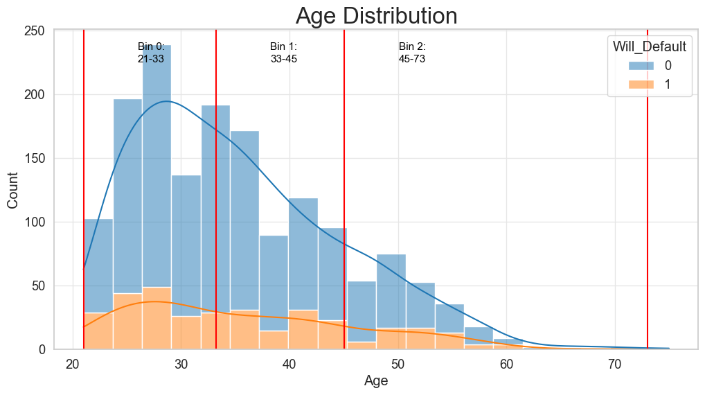

```python
# Plot a histogram of age with cuts at the bin edges
plt.figure(figsize=(12, 6))
sns.histplot(data=df, x='Age', hue='Will_Default', multiple='stack', bins=20, kde=True)

# Set title
plt.title('Age Distribution', fontsize=24)


flat_bin_range = [sublist[0] for sublist in bin_range]
flat_bin_range.append(bin_range[-1][1])

for bin_edge in flat_bin_range:
    plt.axvline(bin_edge, color='red')

# Annotate bin range
for i in range(len(bin_range)):
    plt.annotate(f'Bin {i}:', xy=(bin_range[i][0]+5, 235), fontsize=11, color='black')
    plt.annotate(f'{bin_range[i][0]:.0f}-{bin_range[i][1]:.0f}', xy=(bin_range[i][0]+5, 225), fontsize=11, color='black')



plt.show()
```

*Histogram of age with cuts at the bin edges*

#### **Categorical Encoding**

As our dataset contains categorical data and many machine learning models can only work with numerical values, it is necessary to transform the categorical values of relevant features into numerical ones. This process is known as encoding and there are several ways to encode our data:

1. One Hot Encoder
2. Label Encoder
3. Ordinal Encoder

We will be using One Hot Encoder for our categorical features that are nominal such as Gender and Marraige Status while we will be using Ordinal Encoder for our categorical features that are Ordinal such as Education and AgeBin

```python
X_res_dis_enc, y_res_dis_enc = X_res_dis.copy(), y_res_dis.copy()

# One Hot Encoding
OneHotEnc = OneHotEncoder(categories='auto', sparse=False)
X_res_dis_enc[['Female', 'Male', 'Married', 'Single']] = pd.DataFrame(OneHotEnc.fit_transform(X_res_dis_enc[['Gender', 'Marriage_Status']]))
print('ONE HOT ENCODED VALUES:')
display(X_res_dis_enc[['Gender', 'Female', 'Male', 'Marriage_Status', 'Single', 'Married']].head())

# Ordinal Encoding Education
ordinalEncEdu = OrdinalEncoder(categories=[['high school', 'university', 'post-graduate']], handle_unknown="use_encoded_value", unknown_value=-1)
X_res_dis_enc['EducationEnc'] = ordinalEncEdu.fit_transform(X_res_dis_enc[['Education']])
print('EDUCATION ENCODED VALUES:')
display(X_res_dis_enc[['Education', 'EducationEnc']].head())

# Ordinal Encoding Age
ordinalEncAge = OrdinalEncoder(categories='auto', handle_unknown="use_encoded_value", unknown_value=-1)
X_res_dis_enc['AgeBinEnc'] = ordinalEncAge.fit_transform(X_res_dis_enc[['AgeBin']])
print('AGE ENCODED VALUES:')
display(X_res_dis_enc[['AgeBin', 'AgeBinEnc']].head())
```

```
ONE HOT ENCODED VALUES:
```

|  | Gender | Female | Male | Marriage_Status | Single | Married |
| --- | --- | --- | --- | --- | --- | --- |
| 0 | female | 1.0 | 0.0 | single | 1.0 | 0.0 |
| 1 | male | 0.0 | 1.0 | married | 0.0 | 1.0 |
| 2 | female | 1.0 | 0.0 | single | 1.0 | 0.0 |
| 3 | male | 0.0 | 1.0 | single | 1.0 | 0.0 |
| 4 | male | 0.0 | 1.0 | single | 1.0 | 0.0 |

```
EDUCATION ENCODED VALUES:
```

|  | Education | EducationEnc |
| --- | --- | --- |
| 0 | university | 1.0 |
| 1 | university | 1.0 |
| 2 | post-graduate | 2.0 |
| 3 | post-graduate | 2.0 |
| 4 | high school | 0.0 |

```
AGE ENCODED VALUES:
```

|  | AgeBin | AgeBinEnc |
| --- | --- | --- |
| 0 | 0.0 | 0.0 |
| 1 | 1.0 | 1.0 |
| 2 | 0.0 | 0.0 |
| 3 | 1.0 | 1.0 |
| 4 | 1.0 | 1.0 |

#### **Feature Scaling**

Feature Scaling is the process of scaling numerical features within the dataset to a similar scale.

Certain Machine Learning Algorithms such as `Gradient Descent Based Algorithms` (e.g. Logistic Regression, Ridge Classifier, Perceptron) and `Distance Based Algorithms` (e.g. KNNClassifier and SVC) are more sensitive to feature scaling and requires the data to be scaled.

On the other hand, `Tree Based Algorithms` (e.g. RandomForest, GradientBoosting) are more insensitive to the scale of the features since trees only split a node based on a single feature. This means that other features do not influence this split which explains why different features can be of different scales

There are two popular ways to perform Feature Scaling:

1. Normaliation
2. Standardization

Normalization

Normalization also known as Min-Max scaling, is a scaling technique in which values are shifted and rescaled so that they end up ranging between 0 and 1.

In SKLearn, Normalization can be implemented using `MinMaxScaler`

**Formula**:

$\begin{equation} X' = \frac{X - X_{min}}{X_{max} - X_{min}} \end{equation}$

Standardization

Standardization is another scaling method where values are centered around the mean with a unit standard deviation. This means that the mean of the feautre becomes zero and the distribution of the scaled feature has a unit standard deviation (or a standard deviation of 1).

In SKlearn, Standardization can be implemented using `StandardScaler`

**Formula**:

$\begin{equation} X' = \frac{X - \mu}{\sigma} \end{equation}$

Standardization vs Normalization

| Standardization | Normalization |
| --- | --- |
| Less Sensitive to outliers | Sensitive to outliers |
| Centers data around the mean and scales to a standard deviation of 1 | Rescales values to a range between 0 and 1 |
| Preserves the relationship between data points | May not preserve the relationship between the data points |
| Changes the shape of the original distribution | Retains the shape of the original distribution |

Notice how previously from our EDA, we identified that Bill and Pay contained quite a lot of outliers. Since Standardization is less sensitive to outliers compared to Normalization, it is more likely that scaling our features using Standardization can help improve the performance of our model

```python
X_res_dis_enc_scaled, y_res_dis_enc_scaled = X_res_dis_enc.copy(), y_res_dis_enc.copy()

# Scale the data
scaler = StandardScaler()

numericColumns = ['Credit_Limit', 'Bill1', 'Bill2', 'Bill3', 'Pay1', 'Pay2', 'Pay3']

# Fit the scaler to the training data and transform
X_res_dis_enc_scaled[numericColumns] = scaler.fit_transform(X_res_dis_enc_scaled[numericColumns])
print("SCALED VALUES:")
display(X_res_dis_enc_scaled[numericColumns].head())
```

```
SCALED VALUES:
```

|  | Credit_Limit | Bill1 | Bill2 | Bill3 | Pay1 | Pay2 | Pay3 |
| --- | --- | --- | --- | --- | --- | --- | --- |
| 0 | -1.044256 | -0.317662 | -0.295952 | -0.263005 | -0.272981 | -0.207659 | -0.278168 |
| 1 | 0.299478 | 0.702580 | 0.743468 | 0.780366 | -0.029434 | -0.334396 | -0.062337 |
| 2 | 1.564169 | -0.634713 | -0.676951 | -0.665422 | -0.430444 | -0.334396 | -0.365714 |
| 3 | 1.722255 | -0.570004 | -0.571255 | -0.665450 | -0.426968 | -0.334396 | -0.365714 |
| 4 | -0.253824 | -0.664458 | -0.591437 | -0.665450 | 0.142822 | -0.334247 | -0.284496 |

## 4. Model Selection

In order to select a model for hyperparameter tuning, we will run the preprocessed data through some models and deem the best model based on the evaluation metrics to be chosen later

#### **Pipeline**

First, we will use a pipeline to preprocess the data (the same way as done in part 3) since a pipeline can help:

1. Improve ML Workflow
2. Prevent Data Leakage from the Train subset into the Test subset

Since we are using SMOTE-NC for oversampling, we have to use the ImbalancedLearn pipeline instead of the SKLearn pipeline so that we can implement SMOTE-NC within each cross-validation fold instead of implementing it outside of the CV (which will result in Data Leakage)

```python
# Creating Steps for Pipeline

# Function to log scale data
def log_scale(X):
    df = pd.DataFrame(X.reset_index(drop=True))
    # np.log1p() applies log(1+x) to all elements of the column
    df[['Age']] = np.log1p(df[['Age']])
    return df

# Function to discretize age
def discretize(X):
    df = pd.DataFrame(X.reset_index(drop=True))

    kbins = KBinsDiscretizer(n_bins=9, strategy='kmeans', encode='ordinal')

    # Reshape since kbins require a 2d array as input
    age_bin = kbins.fit_transform(np.array(df['Age']).reshape(-1,1))
    age_bin = pd.Series(age_bin.flatten(), name='AgeBin', dtype='category')

    # Concatenate age_bin at idx
    idx = df.columns.get_loc('Age') + 1
    # Use idx-1 since we no longer need Age as a column since we have ageBin
    return pd.concat((df.iloc[:, :idx-1], age_bin, df.iloc[:, idx:]), axis=1)

# Transformer for categorical columns
categoricalTransformer = ColumnTransformer(
    [
        ('oneHotEncode', OneHotEncoder(categories='auto', sparse=False), ['Gender', 'Marriage_Status']),
        ('ordinalEncodeEducation', OrdinalEncoder(categories=[['high school', 'university', 'post-graduate']], handle_unknown="use_encoded_value", unknown_value=-1), ['Education']),
        ('ordinalEncodeAgeBin', OrdinalEncoder(categories='auto', handle_unknown='use_encoded_value', unknown_value=-1), ['AgeBin'])
    ],
    remainder="passthrough"
)

# Define numeric columns
numeric_cols = ['Credit_Limit', 'Bill1', 'Bill2', 'Bill3', 'Pay1', 'Pay2', 'Pay3']

# Transformer for numeric columns
numericTransformer = ColumnTransformer(
    [
        ('scaling', StandardScaler(), numeric_cols),
    ],
    remainder="passthrough"
)

# Combine the two transformers into preprocessor
preprocessor = ColumnTransformer(
    [
        ("categorical", categoricalTransformer, ['Gender', 'Education', 'Marriage_Status', 'AgeBin']),
        ("numeric", numericTransformer, numeric_cols)
    ],
    remainder="passthrough"
)

steps = [
    ('overSampling', SMOTENC(random_state=random_state, categorical_features=[X_train.columns.get_loc(col) for col in (X_train.select_dtypes(include=['category']).columns)])),
    ('discretization', FunctionTransformer(discretize)),
    ('preprocessor', preprocessor),
    ('model')
]

model_step = len(steps) - 1
```

#### **Evaluation Metrics**

Confusion Matrix:

[figure not shown]

Recall

Recall is used when we want the model to spot as many real 1s as possible

**Formula**: $\begin{equation} Recall = \frac{TP}{TP + FN} \nonumber \end{equation}$

Precision

Precision is used when we want the prediction of 1 to be as correct as possible

**Formula**: $\begin{equation} Precision = \frac{TP}{TP + FP} \nonumber \end{equation}$

Accuracy

Accuracy is used when we are interested in predicting both 0 and 1 correctly and our dataset is balanced enough

**Formula**: $\begin{equation} Accuracy = \frac{TP + TN}{TP + FN + FP + TN} \nonumber \end{equation}$

Balanced Accuracy

Balanced Accuracy is defined as the average of recall obtained on each class and is used to deal with imbalanced datasets

**Formula**: $\begin{equation} Balanced Accuracy = \frac{1}{2}(\frac{TP}{TP + FN} + \frac{TN}{TN + FP}) \nonumber \end{equation}$

F1 Score

F1 is a popular measure for imbalanced dataset and is defined as the harmonic mean between Precision and Recall

**Formula**: $\begin{equation} F1 = \frac{2 \cdot Precision \cdot Recall}{Precision+Recall} \nonumber \end{equation}$

FBeta

In the F1 measure, both recall are equally balanced. The Fbeta-measure is an abstraction of the F-score where the balance of precision and recall in the calculation is controlled by a coefficient called beta. The common weights of beta are:

- F0.5 Score (beta=0.5): More weight on precision, less weight on recall
- F1 Score (beta=1): Balance the weight on precision and recall
- F2 Score (beta=2): More weight on recall, less weight on precision

**Formula**: $\begin{equation} F_\beta = \frac{(1 + \beta^2) \cdot (Precision \cdot Recall)}{(\beta^2 \cdot precision) + recall} \nonumber \end{equation}$

Since the main goal for the financial company is to identify the customers that are likely to default, it is more important to capture as many default cases as possible (i.e. positive cases). However, using recall as an evaluation metric alone is not wise (since a model that does "print(1)" would also have a recall of 1.0).

Hence, it seems better to prioritise recall over precision by using FBeta with beta = 2

As such, we will be using:

- **Balanced Accuracy**
- **FBeta (Beta=2)**
- **ROC AUC**

as our evaluation metrics to try and evaluate our models

Since Scikit learn doesn't have f2 score as one of its metrics under `sklearn.metrics.get_scorer_names()` (this contains all the metrics which can be used for cross_validate and GridSearchCV). As such, we can define our own f2 scorer by using the `make_scorer` function to create a scorer object

```python
# Make custom f2 score (https://scikit-learn.org/stable/modules/model_evaluation.html#scoring-parameter)
ftwo = make_scorer(fbeta_score, beta=2)
evaluation_metrics = {
    "balanced_accuracy": "balanced_accuracy",
    "f2": ftwo,
    "ROC_AUC" : "roc_auc"
}
```

```python
def plot_learning_curve(
    model,
    X,
    y,
    scoring,
    cv=StratifiedKFold(shuffle=True, random_state=random_state),
    train_sizes=np.linspace(0.1, 1.0, 10),
    ax=None,
):
    try:
        model_name = type(model[-1].regressor).__name__
    except:
        try:
            model_name = type(model[-1]).__name__
        except:
            model_name = type(model).__name__
    if ax is None:
        fig, ax = plt.subplots(figsize=(10, 8))
    train_sizes, train_scores, test_scores, fit_times, _ = learning_curve(
        model,
        X,
        y,
        cv=cv,
        n_jobs=-1,
        train_sizes=train_sizes,
        return_times=True,
        scoring=scoring,
    )
    train_scores_mean = np.mean(train_scores, axis=1)
    test_scores_mean = np.mean(test_scores, axis=1)

    ax.plot(train_sizes, train_scores_mean, "o-", color="r", label="Training score")
    ax.plot(
        train_sizes, test_scores_mean, "o-", color="g", label="Cross-validation score"
    )
    ax.legend(loc="best")
    ax.set(
        ylim=(
            min(np.nanmin(train_scores), np.nanmin(test_scores)) - 0.1,
            1.0,
        )
    )
    ax.set_title(f"Learning Curve of {model_name}")
    ax.set_ylabel(f"{scoring}")
    ax.set_xlabel("Train Sizes")
    return ax
```

```python
# Instantiate the models
clfs = [
    ('DecisionTreeClassifier', DecisionTreeClassifier(random_state=random_state)),
    ('RandomForestClassifier', RandomForestClassifier(random_state=random_state)),
    ("GradientBoostingClassifier", GradientBoostingClassifier(random_state=random_state)),
    ("AdaBoostClassifier", AdaBoostClassifier(random_state=random_state)),
    ("LogisticRegression", LogisticRegression(random_state=random_state)),
    ("Perceptron", Perceptron(random_state=random_state)),
    ("KNeighborsClassifier", KNeighborsClassifier()),
    ("GaussianNB", GaussianNB()),
]
```

##### Models Explained

1. `Decision Tree`

A decision tree is the simplest of all tree-based model. The base of the tree is the root node and from the root node flows a series of decision nodes. Each decision node can then be split into further sub-nodes. Nodes that no longer split are called leaf or terminal nodes. The main contributor affecting the decision tree's accuracy is how each decision node is split

2. `Random Forest`

In Random Forest, bagging is used to generate multiple training sets with replacement (i.e. the initial dataset is divided into multiple datasets using randomized sampling). Then a single decision tree is built on each sample before the resultant prediction is combined using either voting or averaging in parallel

3. `Gradient Boosting`

Gradient Boosting is similar to Random Forest in that it is also made up of an ensemble of Decision Trees. However, instead of using a single tree to build on each sample, each new tree is built to improve on the deficiencies of the previous tree (also known as boosting). This is done by minimising the loss function as the algorithm builds each tree

4. `Ada Boost`

AdaBoost, also called Adaptive Boost, is like Gradient Boosting since it also combines a number of weak trees to form a stronger tree. However, AdaBoost was designed for a specific loss function (exponential loss function) while Gradient Boosting is a more generic algorithm that can use any differentiable loss function

5. `Logistic Regression`

Logistic Regression is one of the most simple model for binary classification problems. It fits a sigmoid function

$\begin{equation} S(x) = \frac{1}{1+e^{-x}} \nonumber \end{equation}$

to estimate the probability of an event occuring. A threshold is then set (usually 0.5) which will then predict the class based on the probability

e.g. S(x) >= 0.5 is class 1 while S(x) < 0.5 is class 0

6. `Perceptron`

A perceptron is a single neural network unit that contains weight and biases. It uses an activation function to map the input features to an output and in the case of Binary Classification, this activation function is usually the same Sigmoid function used for logistic regression

7. `KNN Classifier`

In KNN Classifier, the class is predicted based on a vote from its nearest neighbours. The value for n neighbours should be an odd number to try and prevent a tie of vote.

e.g. If the record has 3 neighbours of in the positive class and 2 neighbours of in the negative class, then the record will be predicted as part of the positive class

8. `Gaussian NB`

Gaussian Naive Bayes is a classification technique that based on the probabilistic approach and Gaussian distribution. It is an extension of naive Bayes with the assumption that each feature is independent

$\begin{equation} P(A|B) = \frac{P(B|A)P(A)}{P(B)} \nonumber \end{equation}$

|  | fit_time | score_time | test_balanced_accuracy | train_balanced_accuracy | test_f2 | train_f2 | test_ROC_AUC | train_ROC_AUC |
| --- | --- | --- | --- | --- | --- | --- | --- | --- |
| GaussianNB | 0.111646 | 0.035197 | 0.537596 | 0.539655 | 0.576248 | 0.578009 | 0.552727 | 0.581457 |
| LogisticRegression | 0.133630 | 0.029011 | 0.574813 | 0.588162 | 0.496207 | 0.515823 | 0.594472 | 0.626086 |
| AdaBoostClassifier | 0.334134 | 0.054822 | 0.557326 | 0.670126 | 0.407763 | 0.550670 | 0.603115 | 0.739780 |
| KNeighborsClassifier | 0.111687 | 0.047229 | 0.503497 | 0.753755 | 0.358690 | 0.679819 | 0.524001 | 0.839229 |
| GradientBoostingClassifier | 0.675834 | 0.028062 | 0.565906 | 0.788036 | 0.355484 | 0.684059 | 0.590049 | 0.881808 |
| Perceptron | 0.117046 | 0.030604 | 0.510941 | 0.542264 | 0.355463 | 0.415290 | 0.552892 | 0.569992 |
| DecisionTreeClassifier | 0.132675 | 0.033543 | 0.529040 | 0.996528 | 0.331004 | 0.994437 | 0.529040 | 0.999586 |
| RandomForestClassifier | 0.637280 | 0.063047 | 0.531680 | 0.997979 | 0.240432 | 0.996811 | 0.587485 | 0.999994 |

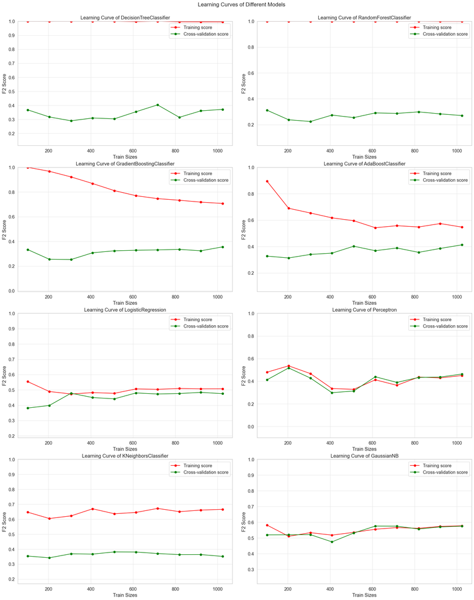

```python
Final_Score = pd.DataFrame()

fig,ax = plt.subplots(4, 2, figsize=(20, 25))
fig.set_facecolor('white')
# Set title
fig.suptitle("Learning Curves of Different Models", fontsize=16)

# Set padding between each subplot
fig.tight_layout(pad=2.5)

for name, clf in clfs:
    steps[model_step] = ('model', clf)
    pipe = Pipeline(steps=steps)
    # Plot learning curve
    plot_learning_curve(
            pipe,
            X_train,
            y_train,
            scoring=ftwo,
            ax=ax[clfs.index((name, clf))//2, clfs.index((name, clf))%2]
        )
    # Edit y-axis label of learning curve
    ax[clfs.index((name, clf))//2, clfs.index((name, clf))%2].set_ylabel("F2 Score")
    # Cross validate
    scores = pd.DataFrame(cross_validate(pipe, X_train, y_train, scoring=evaluation_metrics, cv=10, return_train_score=True, n_jobs=-1)).mean(axis=0)
    Final_Score[name] = scores

display(Final_Score.sort_values(
    by=[
        "test_f2",
        "test_balanced_accuracy",
        "test_ROC_AUC",
    ],
    ascending=False,
    axis=1
).T)
```

**Observations**:

**Initializing Naive Bayes**

```python
# Naive Bayes
steps[model_step] = ("model", GaussianNB())

nb_clf = Pipeline(steps=steps)
nb_clf.fit(X_train, y_train)
scores = pd.DataFrame(cross_validate(
    nb_clf,
    X_train,
    y_train,
    cv=10,
    scoring=evaluation_metrics,
    n_jobs=-1,
    return_train_score=True,
))
scores.loc['mean'] = scores.mean(axis=0)
# displaying scores
display(scores)
```

|  | fit_time | score_time | test_balanced_accuracy | train_balanced_accuracy | test_f2 | train_f2 | test_ROC_AUC | train_ROC_AUC |
| --- | --- | --- | --- | --- | --- | --- | --- | --- |
| 0 | 0.126506 | 0.036877 | 0.545838 | 0.539786 | 0.585586 | 0.579238 | 0.555189 | 0.583104 |
| 1 | 0.136840 | 0.038105 | 0.503850 | 0.545850 | 0.542986 | 0.582451 | 0.504950 | 0.587796 |
| 2 | 0.132850 | 0.041094 | 0.528603 | 0.536478 | 0.555556 | 0.577500 | 0.507884 | 0.581579 |
| 3 | 0.127866 | 0.040098 | 0.527319 | 0.535540 | 0.565611 | 0.575864 | 0.533187 | 0.582625 |
| 4 | 0.140316 | 0.039101 | 0.545838 | 0.545463 | 0.585586 | 0.581102 | 0.535754 | 0.579826 |
| 5 | 0.129349 | 0.039109 | 0.538504 | 0.544196 | 0.560748 | 0.581571 | 0.506051 | 0.583975 |
| 6 | 0.139317 | 0.036586 | 0.550788 | 0.537358 | 0.588235 | 0.575666 | 0.624862 | 0.573404 |
| 7 | 0.139548 | 0.032823 | 0.535937 | 0.538132 | 0.580357 | 0.578368 | 0.606894 | 0.575555 |
| 8 | 0.137527 | 0.029612 | 0.527143 | 0.538248 | 0.586957 | 0.574887 | 0.567143 | 0.584583 |
| 9 | 0.133363 | 0.030829 | 0.572143 | 0.535495 | 0.610860 | 0.573441 | 0.585357 | 0.582125 |
| mean | 0.134348 | 0.036423 | 0.537596 | 0.539655 | 0.576248 | 0.578009 | 0.552727 | 0.581457 |

**Initializing Logistic Regression**

```python
# Logistic Regression
steps[model_step] = ("model", LogisticRegression(random_state=random_state))

logisticRegression_clf = Pipeline(steps=steps)
logisticRegression_clf.fit(X_train, y_train)
scores = pd.DataFrame(cross_validate(
    logisticRegression_clf,
    X_train,
    y_train,
    cv=10,
    scoring=evaluation_metrics,
    n_jobs=-1,
    return_train_score=True,
))
scores.loc['mean'] = scores.mean(axis=0)
# displaying scores
display(scores)
```

|  | fit_time | score_time | test_balanced_accuracy | train_balanced_accuracy | test_f2 | train_f2 | test_ROC_AUC | train_ROC_AUC |
| --- | --- | --- | --- | --- | --- | --- | --- | --- |
| 0 | 0.088745 | 0.034399 | 0.575908 | 0.588453 | 0.505618 | 0.529700 | 0.651999 | 0.619789 |
| 1 | 0.149461 | 0.040101 | 0.432710 | 0.593063 | 0.295858 | 0.503247 | 0.455079 | 0.638391 |
| 2 | 0.145460 | 0.044090 | 0.551155 | 0.593848 | 0.491803 | 0.523511 | 0.551155 | 0.626472 |
| 3 | 0.156423 | 0.041097 | 0.633847 | 0.601811 | 0.605263 | 0.561164 | 0.627063 | 0.633360 |
| 4 | 0.110633 | 0.045788 | 0.585809 | 0.571951 | 0.511364 | 0.492735 | 0.590026 | 0.614414 |
| 5 | 0.155424 | 0.039104 | 0.540154 | 0.572385 | 0.438596 | 0.482625 | 0.583792 | 0.617996 |
| 6 | 0.158647 | 0.040200 | 0.654932 | 0.586295 | 0.607735 | 0.517456 | 0.606894 | 0.635164 |
| 7 | 0.109147 | 0.041293 | 0.604327 | 0.600088 | 0.536723 | 0.541205 | 0.649432 | 0.624242 |
| 8 | 0.158649 | 0.038213 | 0.520000 | 0.590507 | 0.406977 | 0.498696 | 0.562143 | 0.624880 |
| 9 | 0.113135 | 0.037540 | 0.649286 | 0.583222 | 0.562130 | 0.507886 | 0.667143 | 0.626146 |
| mean | 0.134572 | 0.040183 | 0.574813 | 0.588162 | 0.496207 | 0.515823 | 0.594472 | 0.626086 |

**Initializing AdaBoost**

```python
# Adaboost
steps[model_step] = ("model", AdaBoostClassifier(random_state=random_state))

adaBoost_clf = Pipeline(steps=steps)
adaBoost_clf.fit(X_train, y_train)
scores = pd.DataFrame(cross_validate(
    adaBoost_clf,
    X_train,
    y_train,
    cv=10,
    scoring=evaluation_metrics,
    n_jobs=-1,
    return_train_score=True,
))
scores.loc['mean'] = scores.mean(axis=0)
# displaying scores
display(scores)
```

|  | fit_time | score_time | test_balanced_accuracy | train_balanced_accuracy | test_f2 | train_f2 | test_ROC_AUC | train_ROC_AUC |
| --- | --- | --- | --- | --- | --- | --- | --- | --- |
| 0 | 0.373001 | 0.048212 | 0.600843 | 0.691974 | 0.454545 | 0.589273 | 0.630730 | 0.753113 |
| 1 | 0.382380 | 0.050097 | 0.548955 | 0.670686 | 0.387097 | 0.560649 | 0.605244 | 0.743532 |
| 2 | 0.363863 | 0.048212 | 0.480931 | 0.670241 | 0.335366 | 0.553571 | 0.566740 | 0.737401 |
| 3 | 0.376438 | 0.054085 | 0.502017 | 0.676691 | 0.322581 | 0.559943 | 0.510818 | 0.743858 |
| 4 | 0.380746 | 0.039117 | 0.614411 | 0.648730 | 0.480769 | 0.520833 | 0.603594 | 0.720156 |
| 5 | 0.382221 | 0.047108 | 0.505684 | 0.675976 | 0.345912 | 0.561115 | 0.588376 | 0.748840 |
| 6 | 0.385901 | 0.052091 | 0.508251 | 0.666699 | 0.302013 | 0.529630 | 0.564173 | 0.737353 |
| 7 | 0.372851 | 0.043121 | 0.651448 | 0.659098 | 0.537975 | 0.535201 | 0.693803 | 0.726735 |
| 8 | 0.380999 | 0.051870 | 0.565000 | 0.669468 | 0.429448 | 0.541331 | 0.609464 | 0.737461 |
| 9 | 0.379290 | 0.054824 | 0.595714 | 0.671698 | 0.481928 | 0.555158 | 0.658214 | 0.749348 |
| mean | 0.377769 | 0.048874 | 0.557326 | 0.670126 | 0.407763 | 0.550670 | 0.603115 | 0.739780 |

**Compare model with dummy baseline**

```python
# Dummy Classifier
dummy_clf = Pipeline(steps=steps)

steps[model_step] = ("model", DummyClassifier(random_state=random_state, strategy="uniform"))

dummy_clf = Pipeline(steps=steps)
dummy_clf.fit(X_train, y_train)
scores = pd.DataFrame(cross_validate(
    dummy_clf,
    X_train,
    y_train,
    cv=10,
    scoring=evaluation_metrics,
    n_jobs=-1,
    return_train_score=True,
))
scores.loc['mean'] = scores.mean(axis=0)
# displaying scores
display(scores)
```

|  | fit_time | score_time | test_balanced_accuracy | train_balanced_accuracy | test_f2 | train_f2 | test_ROC_AUC | train_ROC_AUC |
| --- | --- | --- | --- | --- | --- | --- | --- | --- |
| 0 | 0.130675 | 0.039319 | 0.438761 | 0.517400 | 0.357143 | 0.414791 | 0.5 | 0.5 |
| 1 | 0.134812 | 0.042278 | 0.509168 | 0.509624 | 0.439560 | 0.405145 | 0.5 | 0.5 |
| 2 | 0.147629 | 0.041904 | 0.509168 | 0.491479 | 0.439560 | 0.382637 | 0.5 | 0.5 |
| 3 | 0.136178 | 0.044767 | 0.556106 | 0.496663 | 0.494505 | 0.389068 | 0.5 | 0.5 |
| 4 | 0.132190 | 0.038786 | 0.438761 | 0.491479 | 0.357143 | 0.382637 | 0.5 | 0.5 |
| 5 | 0.131063 | 0.043290 | 0.579575 | 0.499255 | 0.521978 | 0.392283 | 0.5 | 0.5 |
| 6 | 0.134052 | 0.036723 | 0.485699 | 0.491479 | 0.412088 | 0.382637 | 0.5 | 0.5 |
| 7 | 0.140146 | 0.035725 | 0.509168 | 0.481111 | 0.439560 | 0.369775 | 0.5 | 0.5 |
| 8 | 0.133609 | 0.039826 | 0.541429 | 0.477152 | 0.483871 | 0.364281 | 0.5 | 0.5 |
| 9 | 0.141019 | 0.033985 | 0.541429 | 0.482352 | 0.483871 | 0.370729 | 0.5 | 0.5 |
| mean | 0.136137 | 0.039660 | 0.510926 | 0.493799 | 0.442928 | 0.385398 | 0.5 | 0.5 |

We will be comparing our three models with a dummy baseline model. The comparison will be done through:

- Confusion Matrix
- Learning Curve

**Confusion Matrix**

A confusion Matrix is a table that allows the visualization of the performance of a classification model

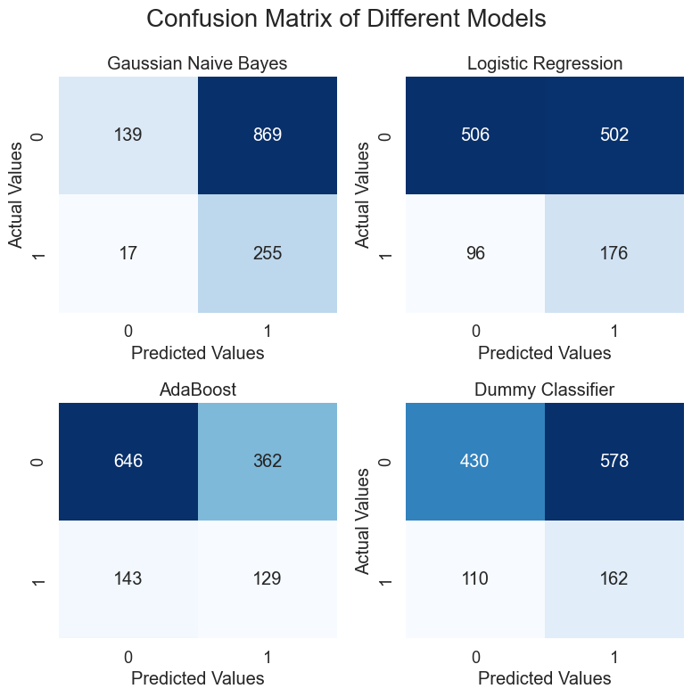

```python
fig, ax = plt.subplots(2, 2, figsize=(8, 8))

plt.suptitle("Confusion Matrix of Different Models", fontsize=20)

# Gaussian Naive Bayes
nb_cm = confusion_matrix(
    y_train, cross_val_predict(nb_clf, X_train, y_train, cv=10)
)
sns.heatmap(nb_cm, annot=True, ax=ax[0, 0], fmt="d", cbar=False, cmap="Blues")
ax[0, 0].set_title("Gaussian Naive Bayes")
ax[0, 0].set_ylabel("Actual Values")
ax[0, 0].set_xlabel("Predicted Values")

# Gradient Boosting Classifier
logisticRegression_cm = confusion_matrix(
    y_train, cross_val_predict(logisticRegression_clf, X_train, y_train, cv=10)
)
sns.heatmap(logisticRegression_cm, annot=True, ax=ax[0, 1], fmt="d", cbar=False, cmap="Blues")
ax[0, 1].set_title("Logistic Regression")
ax[0, 1].set_ylabel("Actual Values")
ax[0, 1].set_xlabel("Predicted Values")

# Gradient Boosting Classifier
adaBoost_cm = confusion_matrix(
    y_train, cross_val_predict(adaBoost_clf, X_train, y_train, cv=10)
)
sns.heatmap(adaBoost_cm, annot=True, ax=ax[1, 0], fmt="d", cbar=False, cmap="Blues")
ax[1, 0].set_title("AdaBoost")
ax[1, 1].set_ylabel("Actual Values")
ax[1, 0].set_xlabel("Predicted Values")

# Dummy Classifier
dummy_cm = confusion_matrix(
    y_train, cross_val_predict(dummy_clf, X_train, y_train, cv=10)
)

sns.heatmap(dummy_cm, annot=True, ax=ax[1, 1], fmt="d", cbar=False, cmap="Blues")
ax[1, 1].set_title("Dummy Classifier")
ax[1, 1].set_ylabel("Actual Values")
ax[1, 1].set_xlabel("Predicted Values")

plt.tight_layout()

plt.show()
```

**Observations**

Since we want our model to accurately predict as many defaulters as possible, we want our True Postive Count to be as high as possible and our False Negative Count to be as low as possible.

From the confusion matrix, it seems that Gaussian Naive Bayes seems to be able to do this quite well with a very low False Negative Count of 17 and a very high True Positive Count of 255.

Although, Gaussian Naive Bayes has a very high False Postive Count of 869, it doesn't matter as much since our main goal is to build a model that can accurately predict customers who are going to default, it's better to have more false alarms that can be filtered out by the bank than for the model to miss an actual customer who will default

**Learning Curve**

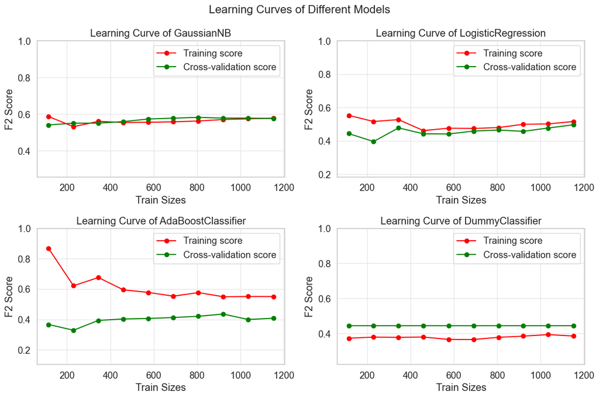

```python
fig, ax = plt.subplots(2, 2, figsize=(12, 8))

plt.suptitle("Learning Curves of Different Models", fontsize=16)

# Naive Bayes Classifier
plot_learning_curve(
    nb_clf,
    X_train,
    y_train,
    scoring=ftwo,
    cv=10,
    ax=ax[0, 0]
)

# Logistic Regression Classifier
plot_learning_curve(
    logisticRegression_clf,
    X_train,
    y_train,
    scoring=ftwo,
    cv=10,
    ax=ax[0, 1]
)

# AdaBoost Classifier
plot_learning_curve(
    adaBoost_clf,
    X_train,
    y_train,
    scoring=ftwo,
    cv=10,
    ax=ax[1, 0]
)

# Dummy Classifier
plot_learning_curve(
    dummy_clf,
    X_train,
    y_train,
    scoring=ftwo,
    cv=10,
    ax=ax[1, 1]
)

# Rewrite y-axis labels
[ax[i, j].set_ylabel("F2 Score") for i in range(2) for j in range(2)]

plt.tight_layout()

plt.show()
```

**Observations**

- From the learning curve, it shows that the learning curve for Dummy Classifier is random and under-fitted since the cross-validation score is constantly greater than the training score
- The learning curve of Naive Bayes, Logistic Regression and Ada Boost seems to improve with a larger training size.
- Since the training score is relatively close to the cross-validation scores for all three models, it seems that there is no overfitting in the three models
- However, the F2 learning curve of Gaussian Naive Bayes still has the best performance out of all the models

## 5. Model Improvement

In order to try and improve the performance of our Naive Bayes and Logistic Regression Models, we can try to tune the hyperparameters of the model

```python
print("Naive Bayes Hyperparameters: ")
print(list(GaussianNB().get_params().keys()))
```

```
Naive Bayes Hyperparameters:
['priors', 'var_smoothing']
```

```python
print("Logistic Regression Hyperparameters: ")
print(list(LogisticRegression().get_params().keys()))
```

```
Logistic Regression Hyperparameters:
['C', 'class_weight', 'dual', 'fit_intercept', 'intercept_scaling', 'l1_ratio', 'max_iter', 'multi_class', 'n_jobs', 'penalty', 'random_state', 'solver', 'tol', 'verbose', 'warm_start']
```

```python
print("AdaBoost Hyperparameters: ")
print(list(AdaBoostClassifier().get_params().keys()))
```

```
AdaBoost Hyperparameters:
['algorithm', 'base_estimator', 'learning_rate', 'n_estimators', 'random_state']
```

**Hyperparameter Tuning and Evaluation**

Hyperparameters to be tuned

- Naive Bayes:
  - var_smoothing => the portion of the largest variance of all features that is added to variances for calculation stability
- Logistic Regression:
  - penalty => type of regularization to be used either l1 (lasso), l2 (ridge), elasticnet (combination of both l1 and l2) or none
  - solver => algorithm used in the optimization problem
  - C => The inverse of regularization strength. Smaller values specify stronger regularization
- AdaBoost
  - algorithm => type of algorithm to be used (either real boosting algorithm or discrete boosting algorithm)
  - n_estimators => the number of estimators at which boosting is terminated
  - learning_rate => Weight applied to each classifier at each boosting iteration. A higher learning rate would increase the contribution of each classifier

```python
# Tuning Naive Bayes
param_grid = {
    "var_smoothing": np.logspace(-10, 0, 100),
}

# Create model using pipeline
steps[model_step] = (
    "tuning",
    GridSearchCV(
        GaussianNB(),
        param_grid,
        cv=10,
        verbose=1,
        n_jobs=-1,
        scoring=ftwo,
    ),
)

nb_GridSearch = Pipeline(steps=steps)

# Fit the model
nb_GridSearch.fit(X_train, y_train)

print(nb_GridSearch.named_steps["tuning"].best_estimator_)
print(nb_GridSearch.named_steps["tuning"].best_params_)
print(nb_GridSearch.named_steps["tuning"].best_score_)
```

```
Fitting 10 folds for each of 100 candidates, totalling 1000 fits
GaussianNB(var_smoothing=1.0)
{'var_smoothing': 1.0}
0.8261793367198937
```

```python
# Tuning Logistic Regression
import warnings
warnings.filterwarnings('ignore')
# Since some solvers don't support L1 regularization, we will turn off warnings for this section
# Create the parameter grid
params_grid = {
    "penalty": ["l1", "l2", "elasticnet", "none"],
    "C": [0.00001, 0.0001, 0.001, 0.01, 0.1, 1, 10, 100],
    "solver": ["newton-cg", "lbfgs", "liblinear", "sag", "saga"]
}

# Creating a model based on the pipeline
steps[model_step] = (
    "tuning",
    GridSearchCV(
        LogisticRegression(random_state=random_state),
        params_grid,
        cv=10,
        verbose=1,
        n_jobs=-1,
        scoring=ftwo,
    ),
)

LogisticRegression_GridSearch = Pipeline(steps=steps)

# Fitting Model
LogisticRegression_GridSearch.fit(X_train, y_train)

print(LogisticRegression_GridSearch.named_steps["tuning"].best_estimator_)
print(LogisticRegression_GridSearch.named_steps["tuning"].best_params_)
print(LogisticRegression_GridSearch.named_steps["tuning"].best_score_)
```

```
Fitting 10 folds for each of 160 candidates, totalling 1600 fits
LogisticRegression(C=1e-05, random_state=42, solver='liblinear')
{'C': 1e-05, 'penalty': 'l2', 'solver': 'liblinear'}
0.7418905163257098
```

```python
# Tuning AdaBoost
params_grid = {
    'algorithm': ['SAMME', 'SAMME.R'],
    'n_estimators': [1, 10, 50, 100, 200, 500],
    'learning_rate': [0.001, 0.01, 0.1, 1.0]
}

# Creating a model based on the pipeline
steps[model_step] = (
    "tuning",
    GridSearchCV(
        AdaBoostClassifier(random_state=random_state),
        params_grid,
        cv=10,
        verbose=1,
        n_jobs=-1,
        scoring=ftwo,
    ),
)

AdaBoost_GridSearch = Pipeline(steps=steps)

# Fitting Model
AdaBoost_GridSearch.fit(X_train, y_train)

print(AdaBoost_GridSearch.named_steps["tuning"].best_estimator_)
print(AdaBoost_GridSearch.named_steps["tuning"].best_params_)
print(AdaBoost_GridSearch.named_steps["tuning"].best_score_)
```

```
Fitting 10 folds for each of 48 candidates, totalling 480 fits
AdaBoostClassifier(algorithm='SAMME', learning_rate=0.01, n_estimators=200,
                   random_state=42)
{'algorithm': 'SAMME', 'learning_rate': 0.01, 'n_estimators': 200}
0.7238845586601703
```

**Model Evaluation**

We will now evaluate the model on an independent test set to see if the model can generalize well to unseen examples

```python
print(y_test.shape)
```

```
(320,)
```

**Initiate model after hyperparameter tuning**

```python
# Naive Bayes
steps[model_step] = ("model", nb_GridSearch.named_steps["tuning"].best_estimator_)
tuned_nb_clf = Pipeline(steps=steps)
# Fit the model
tuned_nb_clf.fit(X_train, y_train)
# Predict the values
nb_y_pred = tuned_nb_clf.predict(X_test)
```

```python
# Logistic Regression
steps[model_step] = ("model", LogisticRegression_GridSearch.named_steps["tuning"].best_estimator_)
tuned_logisticRegression_clf = Pipeline(steps=steps)
# Fit the model
tuned_logisticRegression_clf.fit(X_train, y_train)
# Predict the values
logisticRegression_y_pred = tuned_logisticRegression_clf.predict(X_test)
```

```python
# AdaBoost
steps[model_step] = ("model", AdaBoost_GridSearch.named_steps["tuning"].best_estimator_)
tuned_adaBoost_clf = Pipeline(steps=steps)
# Fit the model
tuned_adaBoost_clf.fit(X_train, y_train)
# Predict the values
adaBoost_y_pred = tuned_adaBoost_clf.predict(X_test)
```

**Comparing the tuned models**

Now, the models will be compared using:

- ROC Curve
- Classification Report
- Confusion Matrix

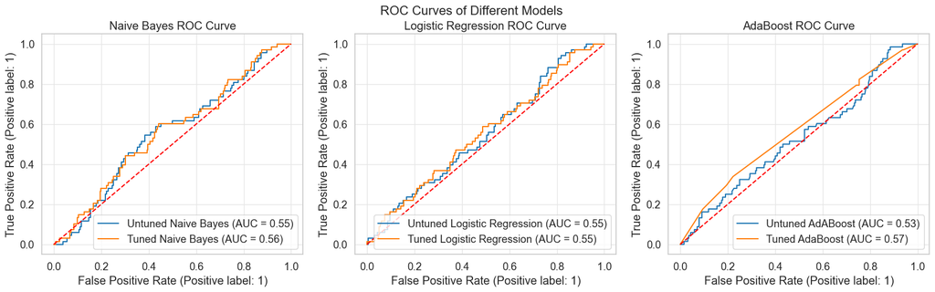

```python
fig, ax= plt.subplots(1, 3, figsize=(20, 5))
# Naive Bayes
RocCurveDisplay.from_estimator(nb_clf, X_test, y_test, ax=ax[0], name="Untuned Naive Bayes")
RocCurveDisplay.from_estimator(tuned_nb_clf, X_test, y_test, ax=ax[0], name="Tuned Naive Bayes")

# Logistic Regression
RocCurveDisplay.from_estimator(logisticRegression_clf, X_test, y_test, ax=ax[1], name="Untuned Logistic Regression")
RocCurveDisplay.from_estimator(tuned_logisticRegression_clf, X_test, y_test, ax=ax[1], name="Tuned Logistic Regression")

# Gradient Boosting
RocCurveDisplay.from_estimator(adaBoost_clf, X_test, y_test, ax=ax[2], name="Untuned AdABoost")
RocCurveDisplay.from_estimator(tuned_adaBoost_clf, X_test, y_test, ax=ax[2], name="Tuned AdaBoost")

# Plot 50% line
[ax[i].plot([0, 1], [0, 1], color="red", linestyle="--") for i in range(3)]

# Set titles
ax[0].set_title("Naive Bayes ROC Curve")
ax[1].set_title("Logistic Regression ROC Curve")
ax[2].set_title("AdaBoost ROC Curve")


plt.suptitle("ROC Curves of Different Models", fontsize=16)

plt.show()
```

**Observations**

- The AUC for naive bayes and AdaBoost seemed to have improved slightly after tuning while the AUC of Logisitic Regression has remained the same
- Overall, the AUC for AdaBoost after tuning seems to have the best performance

```python
# Classification Report
print(f"""
    Naive Bayes Classification Report:
    {classification_report(y_test, nb_y_pred)}

    Logistic Regression Classification Report:
    {classification_report(y_test, logisticRegression_y_pred)}

    AdaBoost Classification Report:
    {classification_report(y_test, adaBoost_y_pred)}

""")
```

```
    Naive Bayes Classification Report:
                  precision    recall  f1-score   support

           0       0.95      0.08      0.14       252
           1       0.22      0.99      0.36        68

    accuracy                           0.27       320
   macro avg       0.59      0.53      0.25       320
weighted avg       0.80      0.27      0.19       320


    Logistic Regression Classification Report:
                  precision    recall  f1-score   support

           0       0.80      0.31      0.44       252
           1       0.22      0.72      0.34        68

    accuracy                           0.39       320
   macro avg       0.51      0.51      0.39       320
weighted avg       0.68      0.39      0.42       320


    AdaBoost Classification Report:
                  precision    recall  f1-score   support

           0       0.82      0.26      0.39       252
           1       0.22      0.79      0.35        68

    accuracy                           0.37       320
   macro avg       0.52      0.53      0.37       320
weighted avg       0.70      0.37      0.38       320
```

**Observations**:

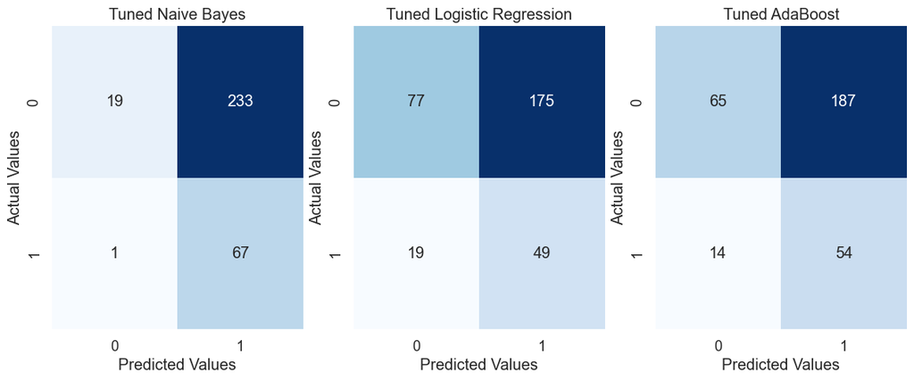

```python
fig, ax = plt.subplots(1, 3, figsize=(14, 5))
# Confusion Matrix
nb_cm = confusion_matrix(y_test, nb_y_pred)
sns.heatmap(nb_cm, annot=True, ax=ax[0], fmt="d", cbar=False, cmap="Blues")
ax[0].set_title("Tuned Naive Bayes")
ax[0].set_ylabel("Actual Values")
ax[0].set_xlabel("Predicted Values")

logisticRegression_cm = confusion_matrix(y_test, logisticRegression_y_pred)
sns.heatmap(logisticRegression_cm, annot=True, ax=ax[1], fmt="d", cbar=False, cmap="Blues")
ax[1].set_title("Tuned Logistic Regression")
ax[1].set_ylabel("Actual Values")
ax[1].set_xlabel("Predicted Values")

adaBoost_cm = confusion_matrix(y_test, adaBoost_y_pred)
sns.heatmap(adaBoost_cm, annot=True, ax=ax[2], fmt="d", cbar=False, cmap="Blues")
ax[2].set_title("Tuned AdaBoost")
ax[2].set_ylabel("Actual Values")
ax[2].set_xlabel("Predicted Values")

plt.show()
```

**Observations**:

- Tuned Naive Bayes managed to score a very high TP of 67 and a very low FN of 1
- On the other hand, Logistic Regression and AdaBoost seem to have a more well rounded performance with a lower FP score but also a lower TP score

```python
pd.DataFrame(
    [
        [balanced_accuracy_score(y_test, nb_y_pred), balanced_accuracy_score(y_test, logisticRegression_y_pred), balanced_accuracy_score(y_test, adaBoost_y_pred)],
        [fbeta_score(y_test, nb_y_pred, beta=2), fbeta_score(y_test, logisticRegression_y_pred, beta=2), fbeta_score(y_test, adaBoost_y_pred, beta=2)],
        [roc_auc_score(y_test, nb_y_pred), roc_auc_score(y_test, logisticRegression_y_pred), roc_auc_score(y_test, adaBoost_y_pred)],
    ],
    columns=["Naive Bayes", "Logistic Regression", "AdaBoost"],
    index=["Balanced Accuracy", "F2 Score", "ROC AUC Score"]
)
```

|  | Naive Bayes | Logistic Regression | AdaBoost |
| --- | --- | --- | --- |
| Balanced Accuracy | 0.530345 | 0.513072 | 0.526027 |
| F2 Score | 0.585664 | 0.493952 | 0.526316 |
| ROC AUC Score | 0.530345 | 0.513072 | 0.526027 |

**Feature Importance**

Although Gaussian Naive Bayes is our best performing model, Naive Bayes works by determining the conditional and unconditional probabilities associated with the features. Thus, there are no coefficients computed or associated with the features used to train the model. As such, we will be extracting the most important features from another model. In this case I will be using Logistic Regression

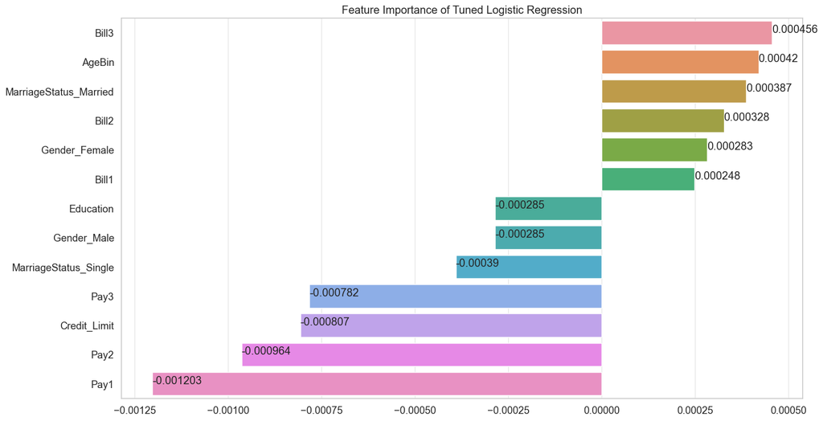

```python
# Show the feature importance for AdaBoost

# Get feature importance of tuned adaBoost
importance = tuned_logisticRegression_clf.named_steps["model"].coef_[0]
# Get the feature names
feature_names = ['Gender_Female', 'Gender_Male', 'MarriageStatus_Married', 'MarriageStatus_Single', 'Education', 'AgeBin', 'Credit_Limit', 'Bill1', 'Bill2', 'Bill3', 'Pay1', 'Pay2', 'Pay3']

# Convert to dataframe
importance_series = pd.Series(importance, index=feature_names).sort_values(ascending=False)

fig, ax = plt.subplots(figsize=(16, 9))
sns.barplot(
    x=importance_series, y=importance_series.index, ax=ax
)
ax.set_title("Feature Importance of Tuned Logistic Regression")
# Set text labels
[ax.text(x=val, y=idx, s=round(val, 6)) for idx, val in zip(np.arange(0,len(importance_series)), importance_series.values)]

plt.show()
```

In Logistic Regression, the coefficients are log-odds (so exponentiating them converts them to odds). A negative coefficient has odds < 1 implying that the odds of the event occuring is lower than the baseline while a positive coefficient has odds > 1 implying that there is an increased odd of the event occuring relative to baseline

**Observation**:

- Since Pay1, Pay2 and Pay3 all have negative coefficients, it suggests that for every one unit increase in pay, the odds of defaulting decreases (since those who paying more suggest they are not in any financial trouble and will end up not defaulting).
- On the other hand, since Bill1, Bill2 and Bill3 all have positive coefficients, it suggests that for every one unit increase in bill, the odds of defaulting increases (since there is a higher chance a customer will not be able to pay a higher bill)
- Females have a slightly higher odds ($e^{0.000283} \approx$ 1.000283) of defaulting compared to males ($e^{-0.000285} \approx$ 0.999715)
- Those who are single have a lower odd ($e^{-0.00039} \approx$ 0.999610) of defaulting compared to those that are married ($e^{0.000387} \approx$ 1.000387)
- With a positive coefficient for AgeBin and a negative coefficient for education, it seems that those who are older people are more likely to default while to those with a higher educational background are less likely to default

**Saving the model**

```python
import os

# Create a folder for the models if it does not exist
if not os.path.exists("models"):
    os.makedirs("models")

#  Save all three models as pickle files
pickle.dump(tuned_nb_clf, open("models/tuned_nb_clf.p", "wb"))
pickle.dump(tuned_logisticRegression_clf, open("models/tuned_logisticRegression_clf.p", "wb"))
pickle.dump(tuned_adaBoost_clf, open("models/tuned_adaBoost_clf.p", "wb"))
```